# RNA-seq analysis plots

First we will import the script which merges count data across all comparisons in all experiments, so we can analyse the raw counts. We’ll also import the results of the differential expression meta-analysis.

```r
# source script for merging count data
source('merge_counts.R')
# import differential expression results
ME_results <- read.csv('data/meta_analysis_results.csv', header = T)
```

Now let’s grab some read mapping statistics from the data sets we imported. For each sample, we’ll extract the number of reads assigned during the alignment step and the number of reads unassigned.

```r
library(reshape2, quietly = T)
library(stringr, quietly = T)

# get number of assigned/unassigned reads
assigned_reads <- lapply(all_counts,
                         function(c) c$stat[c$stat$Status == 'Assigned',-1]
                         )
unassigned_reads <- lapply(all_counts,
                           function(c) apply(c$stat[c$stat$Status != 'Assigned',-1],
                                             2, sum)
                           )

# get metadata columns for our data frame
samples <- lapply(assigned_reads, colnames)
experiments <- lapply(names(all_counts),
                      function(exp_id) rep(exp_id, ncol(all_counts[[exp_id]]$stat) - 1))

# add all the read mapping and sample information to a single data frame
read_mapping_df <- data.frame('assigned' = unlist(assigned_reads),
                              'unassigned' = unlist(unassigned_reads),
                              'sample' = unlist(samples),
                              'experiment' = unlist(experiments))
read_mapping_df <- melt(read_mapping_df, id.vars = c('sample', 'experiment'),
                        variable.name = 'status', value.name = 'num_reads')

# show a preview of the dataframe
head(read_mapping_df)
```

|  | sample | experiment | status | num_reads |
| --- | --- | --- | --- | --- |
| 1 | X.AV.SS.Data.data.mg989.SRP045441.bam.SRR1544483_1_trim.bam | SRP045441 | assigned | 27138840 |
| 2 | X.AV.SS.Data.data.mg989.SRP045441.bam.SRR1544484_1_trim.bam | SRP045441 | assigned | 24640229 |
| 3 | X.AV.SS.Data.data.mg989.SRP045441.bam.SRR1544485_1_trim.bam | SRP045441 | assigned | 27593438 |
| 4 | X.AV.SS.Data.data.mg989.SRP045441.bam.SRR1544489_1_trim.bam | SRP045441 | assigned | 29161911 |
| 5 | X.AV.SS.Data.data.mg989.SRP045441.bam.SRR1544490_1_trim.bam | SRP045441 | assigned | 38711564 |
| 6 | X.AV.SS.Data.data.mg989.SRP045441.bam.SRR1544491_1_trim.bam | SRP045441 | assigned | 31663866 |

Now we can generate a plot showing the percentage of assigned/unassigned reads for each sample.

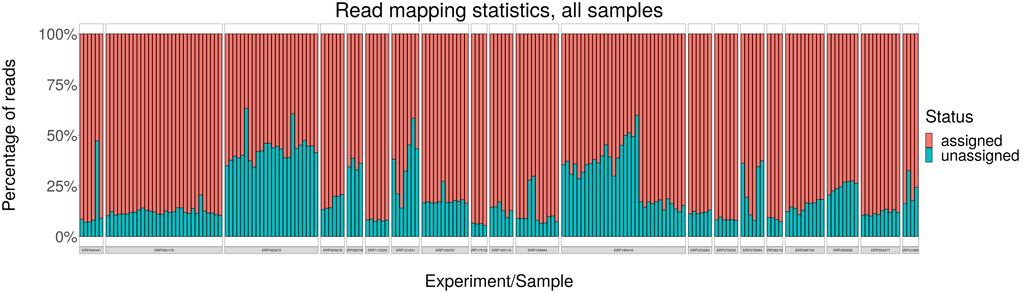

```r
library(ggplot2, quietly = T)

# plot read mapping statistics
read_mapping_plot <- ggplot(read_mapping_df, aes(x = sample, y = num_reads, fill = status)) +
  geom_col(position = 'fill', colour = 'black') +
  scale_y_continuous(labels = scales::percent) +
  facet_grid(~experiment,
             scales = 'free_x',
             space = 'free_x',
             switch = 'x') +
  labs(x = '\nExperiment/Sample', y = 'Percentage of reads\n',
       title = 'Read mapping statistics, all samples',
       fill = 'Status') +
  theme_bw() +
  theme(axis.text.x = element_blank(),
        axis.ticks.x = element_blank(),
        axis.title = element_text(size = 42),
        axis.text.y = element_text(size = 38),
        legend.text = element_text(size = 38),
        legend.title = element_text(size = 42),
        panel.grid = element_blank(),
        plot.title = element_text(size = 50, hjust = 0.5))

print(read_mapping_plot)
```

```r
# save the figure
ggsave('figures/fig1a.png', read_mapping_plot, width = 40, height = 10)
```

Next we can generate some plots to show similarities between samples. To visualise sample relationships, we’ll fit a PCA to the full set of ~16000 genes tested in the meta analysis.

```r
# import sample metadata
sample_metadata <- read.csv('metadata/RNAseq_sample_metadata.csv', row.names = 1)

# make a gene data frame with different ID types for each gene
human_ids <- org.Hs.eg.db
genedata <- data.frame('ensembl' = count_matrix$gene)
genedata$symbol <- mapIds(human_ids,
                          genedata$ensembl,
                          column = 'SYMBOL',
                          keytype = 'ENSEMBL')
genedata$entrez <- mapIds(human_ids,
                          genedata$ensembl,
                          column = 'ENTREZID',
                          keytype = 'ENSEMBL')

# TMM normalise read counts
fixed_effects <- model.matrix(~ senescence_type, data = sample_metadata)
counts_only <- column_to_rownames(count_matrix, 'gene')
normCountMatrix <- preprocessCounts(counts_only,
                                    sample_metadata,
                                    genedata,
                                    fixed_effects)

# get log cpms of the counts
cpms <- cpm(normCountMatrix, log = TRUE)

# subset genes that were tested in the meta-analysis
ME_gene_cpms <- cpms[ME_results$ensembl,]

# run PCA on logged counts
countMatrixPC <- prcomp(t(ME_gene_cpms))
countMatrixPC$x <- as.data.frame(countMatrixPC$x)

# add variables for experiment and type of senescence
countMatrixPC$x$experiment <- sample_metadata$experiment
countMatrixPC$x$senescence_type <- sample_metadata$senescence_type

# calculate percentage of variance explained for each PC
countMatrixPC$var_expl <- countMatrixPC$sd^2 / sum(countMatrixPC$sd^2)
```

Now we can plot the results of the PCA, colouring samples by their experiment ID and type of senescence.

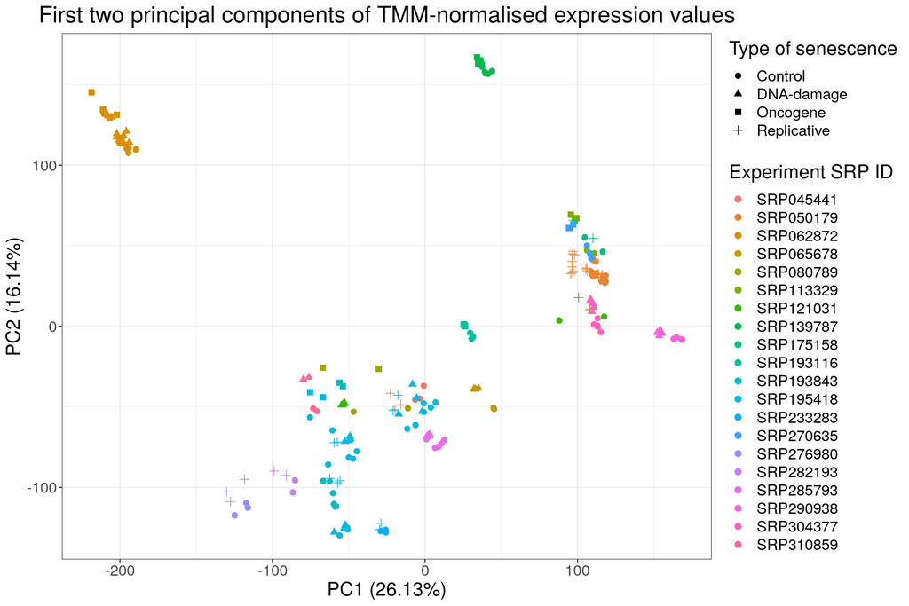

```r
library(ggplot2, quietly = T)

# scatter plot of samples in PCA space
sample_PCA_plot <- ggplot(countMatrixPC$x, aes(x = PC1, y = PC2,
                                               colour = experiment,
                                               shape = senescence_type)) +
  geom_point(size = 2.5) +
  labs(x = paste0('PC1 (', round(countMatrixPC$var_expl[1]*100, 2), '%)'),
       y = paste0('PC2 (', round(countMatrixPC$var_expl[2]*100, 2), '%)'),
       title = 'First two principal components of TMM-normalised expression values',
       colour = 'Experiment SRP ID',
       shape = 'Type of senescence') +
  theme_bw() +
  theme(text = element_text(size = 18),
        plot.title = element_text(hjust = 0.5))

print(sample_PCA_plot)
```

```r
# save the plot
ggsave('figures/pca_plot.png', sample_PCA_plot, width = 12, height = 8)
```

The plot clearly shows some significant batch effects, with samples from individual experiments clustering together more tightly than samples with the same type of senescence. To adjust for these effects, we used a random effects model to model inter-study heterogeneity of log fold changes.

Next we can extract differentially-expressed genes from the fitted model. We’ll use a threshold of BH-adjusted p-value < 0.05 and |log2FC| > 1 for each type of senescence. Any gene that meets this threshold for at least one type of senescence will be classified as “senescence-associated”.

```r
LFC_threshold <- 1

# subset genes identified as differentially-expressed in oncogene-induced senescence
oncogene_sig_mask <- abs(ME_results$LFC_Oncogene) > LFC_threshold & ME_results$adj_p_Oncogene < 0.05
oncogene_sig_genes <- ME_results[oncogene_sig_mask,]

writeLines(paste(nrow(oncogene_sig_genes), 'genes classified as differentially-expressed in oncogene-induced senescence'))
```

```
## 2768 genes classified as differentially-expressed in oncogene-induced senescence
```

```r
# same for replicative senescence
replicative_sig_mask <- abs(ME_results$LFC_Replicative) > LFC_threshold & ME_results$adj_p_Replicative < 0.05
replicative_sig_genes <- ME_results[replicative_sig_mask,]

writeLines(paste(nrow(replicative_sig_genes), 'genes classified as differentially-expressed in replication-induced senescence'))
```

```
## 1471 genes classified as differentially-expressed in replication-induced senescence
```

```r
# same for DNA damage senescence coefficient
DNAdamage_sig_mask <- abs(ME_results$LFC_DNAdamage) > LFC_threshold & ME_results$adj_p_DNAdamage < 0.05
DNAdamage_sig_genes <- ME_results[DNAdamage_sig_mask,]

writeLines(paste(nrow(DNAdamage_sig_genes), 'genes classified as differentially-expressed in DNA damage-induced senescence'))
```

```
## 1588 genes classified as differentially-expressed in DNA damage-induced senescence
```

```r
# combine all DE genes into single vector
RNAseq_senescence_genes <- unique(c(oncogene_sig_genes$ensembl,
                                    replicative_sig_genes$ensembl,
                                    DNAdamage_sig_genes$ensembl))

writeLines(paste(length(RNAseq_senescence_genes), 'genes classified as differentially-expressed in any form of senescence'))
```

```
## 4091 genes classified as differentially-expressed in any form of senescence
```

Now we will import the list of genes taken from the innateDB, cellAge, ageing atlast, and CSgene databases, and join them with the RNA-seq data to generate a full list of senescence-associated genes.

```r
library(dplyr, quietly = T)

# import senescence database genes and get LFCs
senescence_db_genes <- read.csv('data/genesets/senescence_db_genes.csv')
senescence_db_genes$entrez <- as.character(senescence_db_genes$entrez)
senescence_db_genes <- left_join(senescence_db_genes,
                                 genedata[,c('entrez', 'ensembl')],
                                 by = 'entrez')

# filter genes that could not be mapped to ensembl and lookup LFCs
senescence_db_genes <- senescence_db_genes[!is.na(senescence_db_genes$ensembl),]

# combine the full set of senescence genes into a single list for plotting
all_senescence_genes <- list('Oncogene' = oncogene_sig_genes$ensembl,
                             'Replicative' = replicative_sig_genes$ensembl,
                             'DNA-damage' = DNAdamage_sig_genes$ensembl,
                             'Databases' = senescence_db_genes$ensembl)

# get LFCs of senescence database genes
senescence_db_gene_LFCs <- LFClookup(senescence_db_genes$ensembl,
                                     all_senescence_genes[names(all_senescence_genes) != 'Databases'],
                                     column_to_rownames(ME_results, 'ensembl'))
senescence_db_gene_LFCs <- rownames_to_column(senescence_db_gene_LFCs, 'ensembl')
senescence_db_genes <- left_join(senescence_db_genes,
                                 senescence_db_gene_LFCs,
                                 by = 'ensembl')
senescence_db_genes <- column_to_rownames(senescence_db_genes, 'ensembl')

# get LFCs of genes identified via RNA-seq
RNAseq_gene_LFCs <- LFClookup(RNAseq_senescence_genes,
                              all_senescence_genes,
                              column_to_rownames(ME_results, 'ensembl'))

RNAseq_gene_LFCs$ensembl <- RNAseq_senescence_genes
senescence_rnaseq_genes <- left_join(RNAseq_gene_LFCs, genedata, by = 'ensembl')
senescence_rnaseq_genes <- column_to_rownames(senescence_rnaseq_genes, 'ensembl')

# merge senescence db genes with rnaseq genes
all_unique_genes <- unique(c(rownames(senescence_rnaseq_genes),
                             rownames(senescence_db_genes)))
all_genes <- vector(mode = 'list', length = length(all_unique_genes))
for(i in 1:length(all_unique_genes)){
  gene <- all_unique_genes[i]
  if(gene %in% rownames(senescence_db_genes)){
    gene_row <- senescence_db_genes[gene,]
    if(gene %in% rownames(senescence_rnaseq_genes)){
      gene_row$source <- paste(gene_row$source, 'RNAseq', sep = '/')
    }
    all_genes[[i]] <- gene_row
  }
  else if(gene %in% rownames(senescence_rnaseq_genes)){
    gene_row <- senescence_rnaseq_genes[gene,]
    gene_row$source <- 'RNAseq'
    gene_row$senescence_effect <- 'Unknown'
    gene_row$organism <- 'Human'
    all_genes[[i]] <- gene_row
  }
}

# make data frame with all genes
all_genes_df <- do.call(rbind, all_genes)
all_genes_df <- rownames_to_column(all_genes_df, 'ensembl')
all_genes_df$ensembl <- str_replace(all_genes_df$ensembl, '\\..+$', '')

# save the full gene data frame to a csv file
write.csv(all_genes_df, 'data/genesets/all_senescence_genes.csv', row.names = FALSE)
```

To visualise overlap between the different gene sets, we’ll make an upset plot.

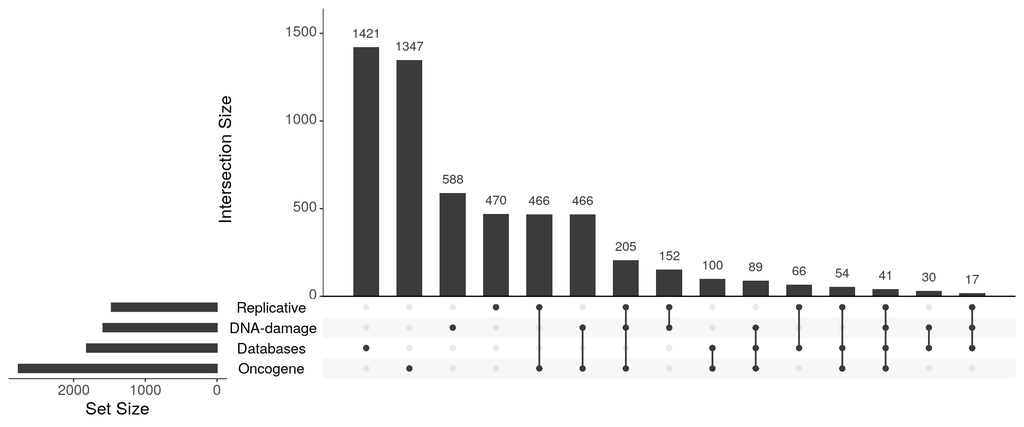

```r
library(UpSetR, quietly = T)

upset_plot_genesets <- upset(fromList(all_senescence_genes), order.by = 'freq', text.scale = 1.75)

print(upset_plot_genesets)
```

```r
# save the figure
png('figures/fig1c.png', width = 2400, height = 2000, units = 'px', res = 300)
upset_plot_genesets
dev.off()
```

We can also make an upset plot showing the overlap between the different databases.

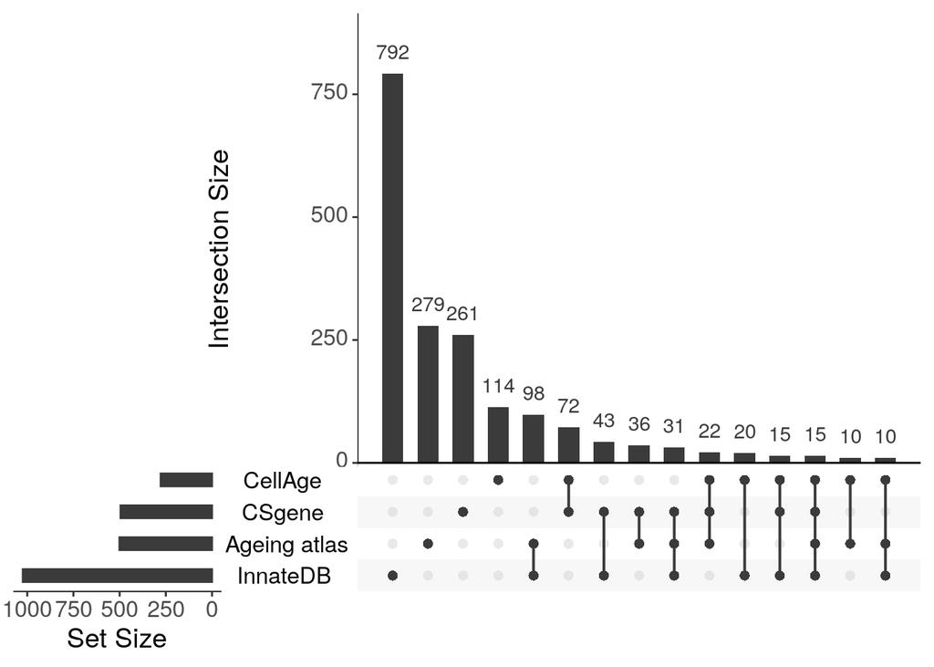

```r
senescence_databases <- unique(unlist(str_split(senescence_db_genes$source, '/')))

db_genes_by_db <- lapply(
  senescence_databases,
  function(db) rownames(senescence_db_genes[grepl(db, senescence_db_genes$source),])
)
names(db_genes_by_db) <- senescence_databases

library(UpSetR, quietly = T)

upset_plot_senescence_dbs <- upset(fromList(db_genes_by_db), order.by = 'freq', text.scale = 1.75)

print(upset_plot_senescence_dbs)
```

```r
# save the figure
png('figures/fig1d.png', width = 2400, height = 2000, units = 'px', res = 300)
upset_plot_senescence_dbs
dev.off()
```

Now we can generate some volcano plots using the LFCs estimated from our mixed model, and their associated (adjusted) p-values.

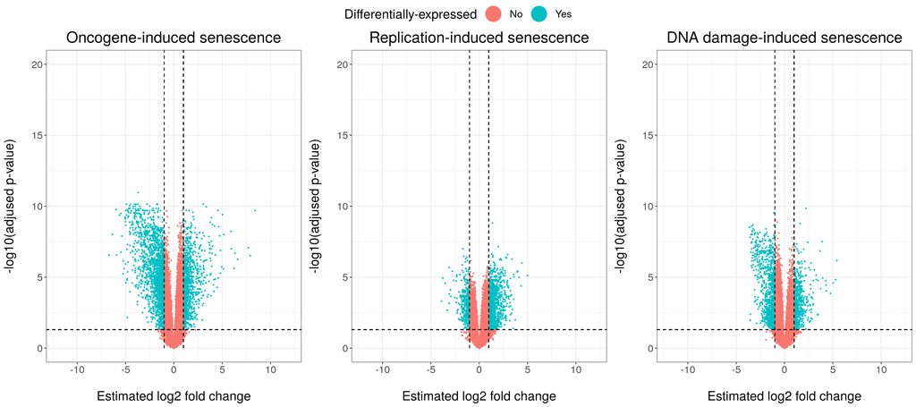

```r
library(ggplot2, quietly = TRUE)
library(ggpubr, quietly = TRUE)

# make volcano plots from the results of DE testing
oncogene_vlcplot <- makeVolcanoPlot(ME_results,
                                    'adj_p_Oncogene',
                                    'LFC_Oncogene',
                                    title = 'Oncogene-induced senescence') +
  xlim(-12, 12) + ylim(0, 20)

replicative_vlcplot <- makeVolcanoPlot(ME_results,
                                       'adj_p_Replicative',
                                       'LFC_Replicative',
                                       title = 'Replication-induced senescence') +
  xlim(-12, 12) + ylim(0, 20)
DNAdamage_vlcplot <- makeVolcanoPlot(ME_results,
                                     'adj_p_DNAdamage',
                                     'LFC_DNAdamage',
                                     title = 'DNA damage-induced senescence') +
  xlim(-12, 12) + ylim(0, 20)

# combine the three volcano plots into a single plot
combined_vlcplot <- ggarrange(oncogene_vlcplot,
                              replicative_vlcplot,
                              DNAdamage_vlcplot,
                              nrow = 1, common.legend = T)

print(combined_vlcplot)
```

```r
# save the figure
ggsave('figures/fig1b.png', combined_vlcplot, width = 18, height = 6)
```